# XAI – Ejercicio 5: Graficos de Dependencia Parcial (PDP)

Ciencia de Datos – Metodos Agnosticos al Modelo

04 de mayo de 2026

# Introduccion

Este informe aplica los **Graficos de Dependencia Parcial (PDP)** a dos tareas de prediccion sobre datos reales. El PDP es un metodo global de interpretabilidad agnostico al modelo que visualiza el efecto marginal de una o dos variables sobre la prediccion de un modelo previamente entrenado. Todos los modelos utilizados son **Bosques Aleatorios (Random Forests)** ajustados mediante el paquete `randomForest`.

La funcion de dependencia parcial se estima como:

$$\hat{f}_{x_S}(x_S) \approx
\frac{1}{n}\sum_{i=1}^{n}\hat{f}(x_S,\, x_C^{(i)})$$

donde $x_S$ es la variable de interes y $x_C$ son el resto de variables marginalizadas sobre los datos. Para cada grafico se evalua una rejilla de **al menos 50 valores equiespaciados**. Las marcas de densidad (*rug marks*) sobre los ejes representan la distribucion empirica de las observaciones de entrenamiento, ayudando a distinguir las regiones bien respaldadas por datos de las posibles extrapolaciones.

# Ejercicio 1 - PDP 1D: Prediccion de Alquiler de Bicicletas

## Preparacion de Datos y Entrenamiento del Modelo

```r
# Librerias
library(randomForest)
library(ggplot2)
library(gridExtra)
library(scales)

# Carga de datos
day <- read.csv("day.csv")

# Variable dias transcurridos desde el 01/01/2011
day$days_since_2011 <- as.numeric(
  as.Date(day$dteday) - as.Date("2011-01-01")
)

# Conjunto de variables predictoras (excluir fecha, id, casual, registered)
features_bike <- c("days_since_2011", "season", "yr", "mnth", "holiday",
                   "weekday", "workingday", "weathersit",
                   "temp", "atemp", "hum", "windspeed")

train_bike <- day[, c(features_bike, "cnt")]

# Entrenamiento del Random Forest con el dataset completo (731 filas)
set.seed(42)
rf_bike <- randomForest(cnt ~ ., data = train_bike, ntree = 500)

cat("Random Forest - Alquiler de Bicicletas\n")
```

```
## Random Forest - Alquiler de Bicicletas
```

```r
cat("OOB R2:", round(1 - rf_bike$mse[500] / var(day$cnt), 3), "\n")
```

```
## OOB R2: 0.892
```

## Funciones Auxiliares para los PDP

```r
# Funcion generica 1D PDP: evalua el modelo sobre una rejilla de >= 50 valores
compute_pdp_1d <- function(model, feature, train_df, n_grid = 50) {
  grid_vals <- seq(min(train_df[[feature]]),
                   max(train_df[[feature]]),
                   length.out = n_grid)
  pdp_vals <- sapply(grid_vals, function(v) {
    tmp            <- train_df
    tmp[[feature]] <- v
    mean(predict(model, newdata = tmp))
  })
  data.frame(x = grid_vals, yhat = pdp_vals)
}

# Funcion de visualizacion (linea + rug, estilo diapositivas de clase)
plot_pdp_bike <- function(pdp_df, x_label, train_df, feature,
                          y_limits = c(0, 5500)) {
  ggplot(pdp_df, aes(x = x, y = yhat)) +
    geom_line(colour = "black", linewidth = 0.9) +
    geom_rug(
      data        = train_df,
      aes_string(x = feature),
      sides       = "b",
      alpha       = 0.4,
      colour      = "black",
      inherit.aes = FALSE
    ) +
    scale_y_continuous(limits = y_limits,
                       breaks = seq(0, 5000, by = 1000)) +
    labs(x = x_label, y = "Numero predicho de alquileres de bicicletas") +
    theme_bw(base_size = 11) +
    theme(panel.grid.minor = element_blank())
}
```

## Resultados

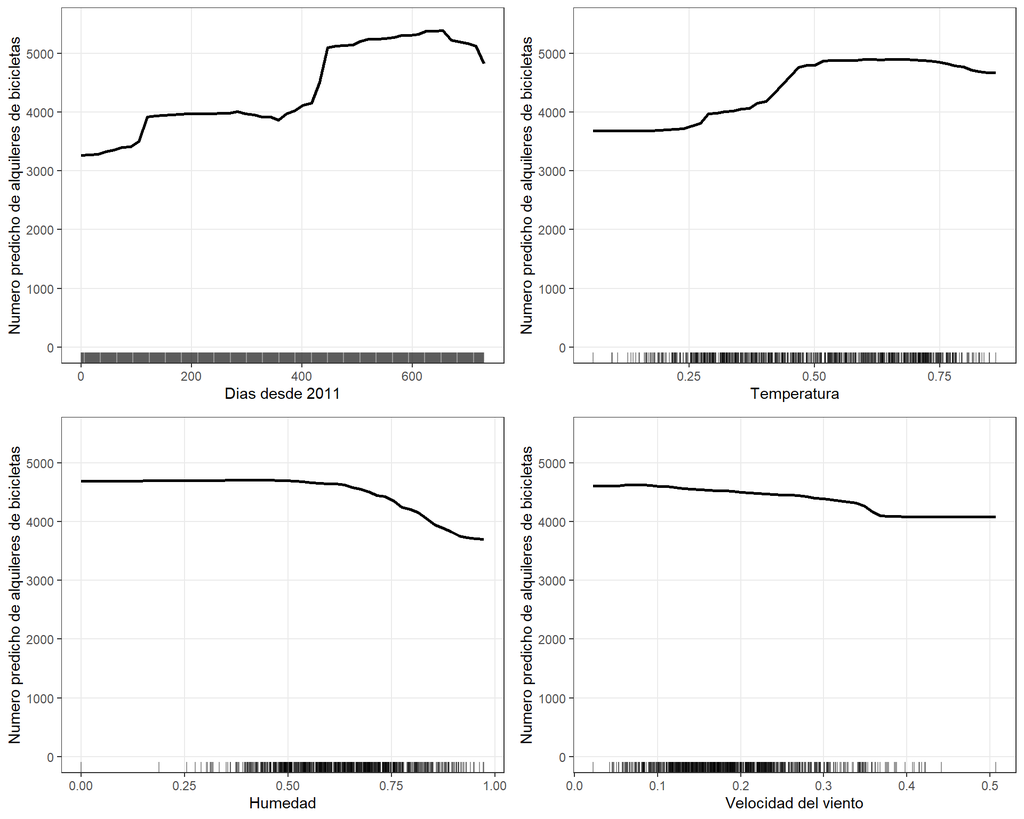

```r
# Calcular los cuatro PDP 1D (50 puntos de rejilla cada uno)
pdp_days <- compute_pdp_1d(rf_bike, "days_since_2011", train_bike)
pdp_temp <- compute_pdp_1d(rf_bike, "temp",            train_bike)
pdp_hum  <- compute_pdp_1d(rf_bike, "hum",             train_bike)
pdp_wind <- compute_pdp_1d(rf_bike, "windspeed",       train_bike)

# Construir los graficos
p1 <- plot_pdp_bike(pdp_days, "Dias desde 2011",      day, "days_since_2011")
p2 <- plot_pdp_bike(pdp_temp, "Temperatura",          day, "temp")
p3 <- plot_pdp_bike(pdp_hum,  "Humedad",              day, "hum")
p4 <- plot_pdp_bike(pdp_wind, "Velocidad del viento", day, "windspeed")

grid.arrange(p1, p2, p3, p4, ncol = 2)
```

## Analisis

**Dias desde 2011** muestra una tendencia positiva clara y aproximadamente monotona. Los alquileres predichos crecen de forma sostenida a lo largo del tiempo, reflejando la adopcion progresiva del servicio durante 2011 y 2012. El modelo ha capturado un fuerte efecto temporal que probablemente recoge tanto la estacionalidad como el crecimiento interanual de la demanda. Las marcas de densidad confirman que las observaciones cubren todo el rango temporal sin huecos.

**Temperatura** presenta una relacion no lineal en forma de U invertida. Los alquileres aumentan con fuerza desde valores frios hasta temperaturas moderadas, alcanzan un maximo y luego se estabilizan o descienden ligeramente en los valores mas altos. Tanto el frio extremo como el calor excesivo desincentivan el uso de la bicicleta, comportamiento que el modelo captura con eficacia.

**Humedad** tiene un efecto predominantemente negativo. Los alquileres predichos se mantienen relativamente estables con humedades bajas o moderadas, pero caen de forma notable al aumentar la humedad, lo que es coherente con las condiciones de lluvia o incomodidad que disuaden a los usuarios. Las marcas de densidad muestran que la mayoria de las observaciones se concentran en el rango medio.